# 297.101: Homework 3

Author

TOM SIACKHASONE

The data for today is daily counts of those walking or cycling over the He Ara Kotahi bridge across the Manawatu river in Palmerston North. The following code block reads these data in and wrangles them into the correct form for charting. **Don’t change this code block.**

```r
library(tidyverse)

bridge <- read_csv("https://www.massey.ac.nz/~jcmarsha/data/pncc_cycle_counts/he_ara_kotahi_one_year.csv") |>
  group_by(Date) |> summarise(Count = sum(Count)) |>
  mutate(Day = wday(Date, label=TRUE, abbr = FALSE)) |>
  select(Day, Count)
```

## Task

Use the code chunk below to produce a chart summarising the **distribution** of the `Count` for each `Day` of the week.

- *The `Day` grouping variable has 7 possible values, so consider the best type of display for this many groups.*
- *Ensure you label the axes of your chart appropriately.*
- *Choose a title, subtitle or both that help tell the story.*

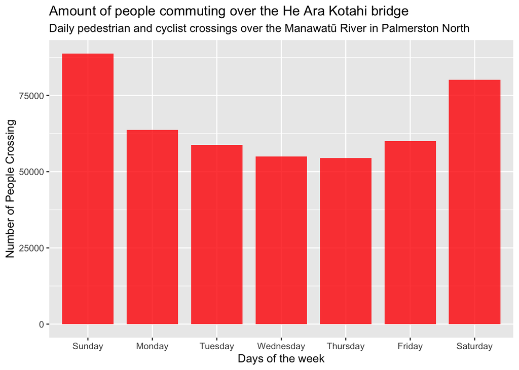

```r
ggplot(data=bridge) +
aes(x = Day, y = Count) +
geom_col(width= 0.8, fill="red", alpha=0.8) +
labs(x = "Days of the week", y = "Number of People Crossing", title = "Amount of people commuting over the He Ara Kotahi bridge", subtitle = "Daily pedestrian and cyclist crossings over the Manawatū River in Palmerston North")
```

Weekends, especially Sunday, look like the business most likely used as a nice walk. Weekdays are steadier, with the middle of the week dipping

## Submission

- *Make sure you fill in your name in the `author` field at the top.*
- *Once you are happy with your chart, “Render” this .qmd file to produce a .html file.*
- *Submit the resulting .html file to stream.*